# Risk Factor Analysis

## Outcome Variable

**Outcome Variable:** ever_co

## Predictor Variables

**Intervention Variable:** feducyrs

**Adjustment Set:**

- arm
- W_mage
- meducyrs
- hhwealth_quart
- W_mhtcm
- W_mwtkg
- W_mbmi
- W_gagebrth
- W_birthwt
- W_birthlen
- single
- delta_W_mage
- delta_meducyrs
- delta_hhwealth_quart
- delta_W_mhtcm
- delta_W_mwtkg
- delta_W_mbmi
- delta_W_gagebrth
- delta_W_birthwt
- delta_W_birthlen
- delta_single

## Stratifying Variables

The analysis was stratified on these variable(s):

- agecat
- studyid
- country

## Data Summary

| agecat | studyid | country | feducyrs | ever_co | n_cell | n |
| --- | --- | --- | --- | --- | --- | --- |
| 0-24 months | COHORTS | GUATEMALA | High | 0 | 203 | 1234 |
| 0-24 months | COHORTS | GUATEMALA | High | 1 | 28 | 1234 |
| 0-24 months | COHORTS | GUATEMALA | Low | 0 | 497 | 1234 |
| 0-24 months | COHORTS | GUATEMALA | Low | 1 | 61 | 1234 |
| 0-24 months | COHORTS | GUATEMALA | Medium | 0 | 395 | 1234 |
| 0-24 months | COHORTS | GUATEMALA | Medium | 1 | 50 | 1234 |
| 0-24 months | COHORTS | INDIA | High | 0 | 538 | 1447 |
| 0-24 months | COHORTS | INDIA | High | 1 | 29 | 1447 |
| 0-24 months | COHORTS | INDIA | Low | 0 | 412 | 1447 |
| 0-24 months | COHORTS | INDIA | Low | 1 | 60 | 1447 |
| 0-24 months | COHORTS | INDIA | Medium | 0 | 388 | 1447 |
| 0-24 months | COHORTS | INDIA | Medium | 1 | 20 | 1447 |
| 0-24 months | COHORTS | PHILIPPINES | High | 0 | 916 | 2868 |
| 0-24 months | COHORTS | PHILIPPINES | High | 1 | 112 | 2868 |
| 0-24 months | COHORTS | PHILIPPINES | Low | 0 | 619 | 2868 |
| 0-24 months | COHORTS | PHILIPPINES | Low | 1 | 207 | 2868 |
| 0-24 months | COHORTS | PHILIPPINES | Medium | 0 | 803 | 2868 |
| 0-24 months | COHORTS | PHILIPPINES | Medium | 1 | 211 | 2868 |
| 0-24 months | GMS-Nepal | NEPAL | High | 0 | 125 | 684 |
| 0-24 months | GMS-Nepal | NEPAL | High | 1 | 44 | 684 |
| 0-24 months | GMS-Nepal | NEPAL | Low | 0 | 197 | 684 |
| 0-24 months | GMS-Nepal | NEPAL | Low | 1 | 95 | 684 |
| 0-24 months | GMS-Nepal | NEPAL | Medium | 0 | 160 | 684 |
| 0-24 months | GMS-Nepal | NEPAL | Medium | 1 | 63 | 684 |
| 0-24 months | JiVitA-3 | BANGLADESH | High | 0 | 6064 | 25939 |
| 0-24 months | JiVitA-3 | BANGLADESH | High | 1 | 410 | 25939 |
| 0-24 months | JiVitA-3 | BANGLADESH | Low | 0 | 9558 | 25939 |
| 0-24 months | JiVitA-3 | BANGLADESH | Low | 1 | 1058 | 25939 |
| 0-24 months | JiVitA-3 | BANGLADESH | Medium | 0 | 8028 | 25939 |
| 0-24 months | JiVitA-3 | BANGLADESH | Medium | 1 | 821 | 25939 |

[output cut: 330 more lines]

The following strata were considered:

- agecat: 0-24 months, studyid: COHORTS, country: GUATEMALA
- agecat: 0-24 months, studyid: COHORTS, country: INDIA
- agecat: 0-24 months, studyid: COHORTS, country: PHILIPPINES
- agecat: 0-24 months, studyid: GMS-Nepal, country: NEPAL
- agecat: 0-24 months, studyid: JiVitA-3, country: BANGLADESH
- agecat: 0-24 months, studyid: JiVitA-4, country: BANGLADESH
- agecat: 0-24 months, studyid: LCNI-5, country: MALAWI
- agecat: 0-24 months, studyid: MAL-ED, country: BANGLADESH
- agecat: 0-24 months, studyid: MAL-ED, country: INDIA
- agecat: 0-24 months, studyid: MAL-ED, country: NEPAL
- agecat: 0-24 months, studyid: MAL-ED, country: PERU
- agecat: 0-24 months, studyid: MAL-ED, country: SOUTH AFRICA
- agecat: 0-24 months, studyid: MAL-ED, country: TANZANIA, UNITED REPUBLIC OF
- agecat: 0-24 months, studyid: NIH-Crypto, country: BANGLADESH
- agecat: 0-24 months, studyid: PROBIT, country: BELARUS
- agecat: 0-24 months, studyid: PROVIDE, country: BANGLADESH
- agecat: 0-24 months, studyid: SAS-CompFeed, country: INDIA
- agecat: 0-24 months, studyid: SAS-FoodSuppl, country: INDIA
- agecat: 0-24 months, studyid: TanzaniaChild2, country: TANZANIA, UNITED REPUBLIC OF
- agecat: 0-24 months, studyid: ZVITAMBO, country: ZIMBABWE
- agecat: 0-6 months, studyid: COHORTS, country: GUATEMALA
- agecat: 0-6 months, studyid: COHORTS, country: INDIA
- agecat: 0-6 months, studyid: COHORTS, country: PHILIPPINES
- agecat: 0-6 months, studyid: GMS-Nepal, country: NEPAL
- agecat: 0-6 months, studyid: JiVitA-3, country: BANGLADESH
- agecat: 0-6 months, studyid: JiVitA-4, country: BANGLADESH
- agecat: 0-6 months, studyid: LCNI-5, country: MALAWI
- agecat: 0-6 months, studyid: MAL-ED, country: BANGLADESH
- agecat: 0-6 months, studyid: MAL-ED, country: INDIA
- agecat: 0-6 months, studyid: MAL-ED, country: NEPAL
- agecat: 0-6 months, studyid: MAL-ED, country: PERU
- agecat: 0-6 months, studyid: MAL-ED, country: SOUTH AFRICA
- agecat: 0-6 months, studyid: MAL-ED, country: TANZANIA, UNITED REPUBLIC OF
- agecat: 0-6 months, studyid: NIH-Crypto, country: BANGLADESH
- agecat: 0-6 months, studyid: PROBIT, country: BELARUS
- agecat: 0-6 months, studyid: PROVIDE, country: BANGLADESH
- agecat: 0-6 months, studyid: SAS-CompFeed, country: INDIA
- agecat: 0-6 months, studyid: SAS-FoodSuppl, country: INDIA
- agecat: 0-6 months, studyid: TanzaniaChild2, country: TANZANIA, UNITED REPUBLIC OF
- agecat: 0-6 months, studyid: ZVITAMBO, country: ZIMBABWE
- agecat: 6-24 months, studyid: COHORTS, country: GUATEMALA
- agecat: 6-24 months, studyid: COHORTS, country: INDIA
- agecat: 6-24 months, studyid: COHORTS, country: PHILIPPINES
- agecat: 6-24 months, studyid: GMS-Nepal, country: NEPAL
- agecat: 6-24 months, studyid: JiVitA-3, country: BANGLADESH
- agecat: 6-24 months, studyid: JiVitA-4, country: BANGLADESH
- agecat: 6-24 months, studyid: LCNI-5, country: MALAWI
- agecat: 6-24 months, studyid: MAL-ED, country: BANGLADESH
- agecat: 6-24 months, studyid: MAL-ED, country: INDIA
- agecat: 6-24 months, studyid: MAL-ED, country: NEPAL
- agecat: 6-24 months, studyid: MAL-ED, country: PERU
- agecat: 6-24 months, studyid: MAL-ED, country: SOUTH AFRICA
- agecat: 6-24 months, studyid: MAL-ED, country: TANZANIA, UNITED REPUBLIC OF
- agecat: 6-24 months, studyid: NIH-Crypto, country: BANGLADESH
- agecat: 6-24 months, studyid: PROBIT, country: BELARUS
- agecat: 6-24 months, studyid: PROVIDE, country: BANGLADESH
- agecat: 6-24 months, studyid: SAS-CompFeed, country: INDIA
- agecat: 6-24 months, studyid: SAS-FoodSuppl, country: INDIA
- agecat: 6-24 months, studyid: TanzaniaChild2, country: TANZANIA, UNITED REPUBLIC OF
- agecat: 6-24 months, studyid: ZVITAMBO, country: ZIMBABWE

### Dropped Strata

Some strata were dropped due to rare outcomes:

- agecat: 0-24 months, studyid: MAL-ED, country: BANGLADESH
- agecat: 0-24 months, studyid: MAL-ED, country: NEPAL
- agecat: 0-24 months, studyid: MAL-ED, country: PERU
- agecat: 0-24 months, studyid: MAL-ED, country: SOUTH AFRICA
- agecat: 0-24 months, studyid: MAL-ED, country: TANZANIA, UNITED REPUBLIC OF
- agecat: 0-24 months, studyid: PROBIT, country: BELARUS
- agecat: 0-6 months, studyid: COHORTS, country: GUATEMALA
- agecat: 0-6 months, studyid: LCNI-5, country: MALAWI
- agecat: 0-6 months, studyid: MAL-ED, country: BANGLADESH
- agecat: 0-6 months, studyid: MAL-ED, country: INDIA
- agecat: 0-6 months, studyid: MAL-ED, country: NEPAL
- agecat: 0-6 months, studyid: MAL-ED, country: PERU
- agecat: 0-6 months, studyid: MAL-ED, country: SOUTH AFRICA
- agecat: 0-6 months, studyid: MAL-ED, country: TANZANIA, UNITED REPUBLIC OF
- agecat: 0-6 months, studyid: NIH-Crypto, country: BANGLADESH
- agecat: 0-6 months, studyid: PROBIT, country: BELARUS
- agecat: 0-6 months, studyid: TanzaniaChild2, country: TANZANIA, UNITED REPUBLIC OF
- agecat: 6-24 months, studyid: MAL-ED, country: BANGLADESH
- agecat: 6-24 months, studyid: MAL-ED, country: NEPAL
- agecat: 6-24 months, studyid: MAL-ED, country: PERU
- agecat: 6-24 months, studyid: MAL-ED, country: SOUTH AFRICA
- agecat: 6-24 months, studyid: MAL-ED, country: TANZANIA, UNITED REPUBLIC OF
- agecat: 6-24 months, studyid: PROBIT, country: BELARUS

## Methods Detail

We’re interested in the causal parameters $E[Y_a]$ for all values of $a \in \mathcal{A}$. These parameters represent the mean outcome if, possibly contrary to fact, we intervened to set all units to have $A=a$. Under the randomization and positivity assumptions, these are identified by the statistical parameters $\psi_a=E_W[E_{Y|A,W}(Y|A=a,W)]$. In addition, we’re interested in the mean of $Y$, $E[Y]$ under no intervention (the observed mean). We will estimate these parameters by using SuperLearner to fit the relevant likelihood factors – $E_{Y|A,W}(Y|A=a,W)$ and $p(A=a|W)$, and then updating our likelihood fit using a joint TMLE.

For unadjusted analyses ($W=\{\}$), initial likelihoods were estimated using Lrnr_glm to estimate the simple $E(Y|A)$ and Lrnr_mean to estimate $p(A)$. For adjusted analyses, a small library containing Lrnr_glmnet, Lrnr_xgboost, and Lrnr_mean was used.

Having estimated these parameters, we will then use the delta method to estimate relative risks and attributable risks relative to a prespecified baseline level of $A$.

# Results Detail

## Results Plots

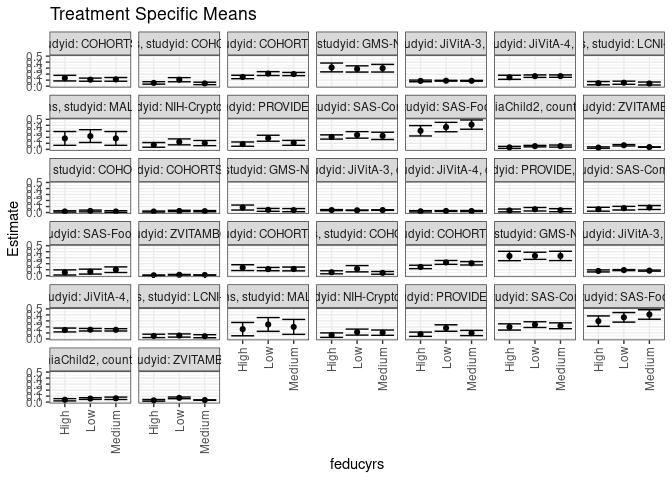

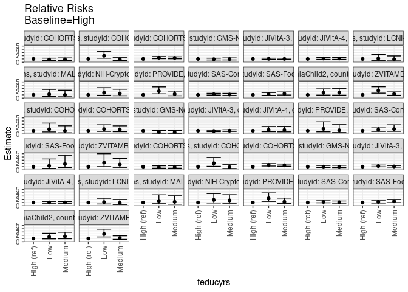

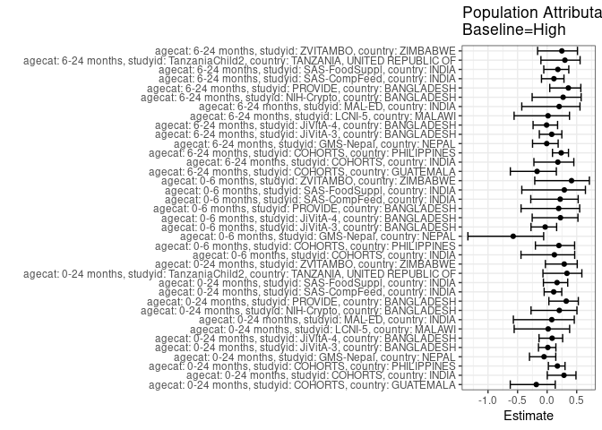

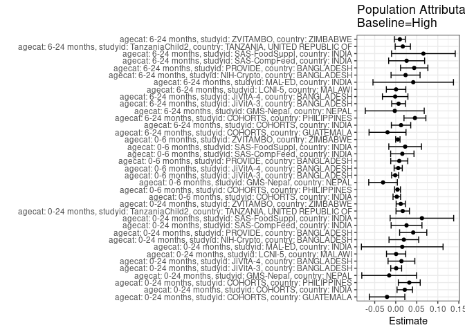

## Results Table

### Parameter: TSM

| agecat | studyid | country | intervention_level | baseline_level | estimate | ci_lower | ci_upper |
| --- | --- | --- | --- | --- | --- | --- | --- |
| 0-24 months | COHORTS | GUATEMALA | High | NA | 0.1332903 | 0.0866091 | 0.1799715 |
| 0-24 months | COHORTS | GUATEMALA | Low | NA | 0.1080921 | 0.0820530 | 0.1341312 |
| 0-24 months | COHORTS | GUATEMALA | Medium | NA | 0.1124113 | 0.0817052 | 0.1431173 |
| 0-24 months | COHORTS | INDIA | High | NA | 0.0538379 | 0.0334781 | 0.0741976 |
| 0-24 months | COHORTS | INDIA | Low | NA | 0.1074412 | 0.0730768 | 0.1418056 |
| 0-24 months | COHORTS | INDIA | Medium | NA | 0.0452383 | 0.0248911 | 0.0655856 |
| 0-24 months | COHORTS | PHILIPPINES | High | NA | 0.1526303 | 0.1242213 | 0.1810393 |
| 0-24 months | COHORTS | PHILIPPINES | Low | NA | 0.2091473 | 0.1772822 | 0.2410123 |
| 0-24 months | COHORTS | PHILIPPINES | Medium | NA | 0.2014696 | 0.1745654 | 0.2283739 |
| 0-24 months | GMS-Nepal | NEPAL | High | NA | 0.3108854 | 0.2375212 | 0.3842496 |
| 0-24 months | GMS-Nepal | NEPAL | Low | NA | 0.2860587 | 0.2341394 | 0.3379781 |
| 0-24 months | GMS-Nepal | NEPAL | Medium | NA | 0.2981096 | 0.2345446 | 0.3616746 |
| 0-24 months | JiVitA-3 | BANGLADESH | High | NA | 0.0872019 | 0.0735501 | 0.1008536 |
| 0-24 months | JiVitA-3 | BANGLADESH | Low | NA | 0.0904270 | 0.0833412 | 0.0975129 |
| 0-24 months | JiVitA-3 | BANGLADESH | Medium | NA | 0.0886668 | 0.0814971 | 0.0958364 |
| 0-24 months | JiVitA-4 | BANGLADESH | High | NA | 0.1471630 | 0.1133842 | 0.1809419 |
| 0-24 months | JiVitA-4 | BANGLADESH | Low | NA | 0.1660136 | 0.1454165 | 0.1866108 |
| 0-24 months | JiVitA-4 | BANGLADESH | Medium | NA | 0.1670435 | 0.1474815 | 0.1866055 |
| 0-24 months | LCNI-5 | MALAWI | High | NA | 0.0495292 | 0.0224252 | 0.0766331 |
| 0-24 months | LCNI-5 | MALAWI | Low | NA | 0.0567898 | 0.0305353 | 0.0830442 |
| 0-24 months | LCNI-5 | MALAWI | Medium | NA | 0.0437818 | 0.0192700 | 0.0682937 |
| 0-24 months | MAL-ED | INDIA | High | NA | 0.1818182 | 0.0674652 | 0.2961712 |
| 0-24 months | MAL-ED | INDIA | Low | NA | 0.2203390 | 0.1142176 | 0.3264604 |
| 0-24 months | MAL-ED | INDIA | Medium | NA | 0.1818182 | 0.0674652 | 0.2961712 |
| 0-24 months | NIH-Crypto | BANGLADESH | High | NA | 0.0743798 | 0.0354606 | 0.1132990 |
| 0-24 months | NIH-Crypto | BANGLADESH | Low | NA | 0.1241270 | 0.0748934 | 0.1733605 |
| 0-24 months | NIH-Crypto | BANGLADESH | Medium | NA | 0.1041743 | 0.0615764 | 0.1467721 |
| 0-24 months | PROVIDE | BANGLADESH | High | NA | 0.0870363 | 0.0513968 | 0.1226759 |
| 0-24 months | PROVIDE | BANGLADESH | Low | NA | 0.1849177 | 0.1349197 | 0.2349156 |
| 0-24 months | PROVIDE | BANGLADESH | Medium | NA | 0.1081212 | 0.0674925 | 0.1487498 |

[output cut: 81 more lines]

### Parameter: E(Y)

| agecat | studyid | country | intervention_level | baseline_level | estimate | ci_lower | ci_upper |
| --- | --- | --- | --- | --- | --- | --- | --- |
| 0-24 months | COHORTS | GUATEMALA | NA | NA | 0.1126418 | 0.0949950 | 0.1302886 |
| 0-24 months | COHORTS | INDIA | NA | NA | 0.0753283 | 0.0617252 | 0.0889313 |
| 0-24 months | COHORTS | PHILIPPINES | NA | NA | 0.1847978 | 0.1705903 | 0.1990052 |
| 0-24 months | GMS-Nepal | NEPAL | NA | NA | 0.2953216 | 0.2611095 | 0.3295338 |
| 0-24 months | JiVitA-3 | BANGLADESH | NA | NA | 0.0882455 | 0.0842753 | 0.0922157 |
| 0-24 months | JiVitA-4 | BANGLADESH | NA | NA | 0.1607278 | 0.1492347 | 0.1722209 |
| 0-24 months | LCNI-5 | MALAWI | NA | NA | 0.0504305 | 0.0353790 | 0.0654820 |
| 0-24 months | MAL-ED | INDIA | NA | NA | 0.1972789 | 0.1327292 | 0.2618286 |
| 0-24 months | NIH-Crypto | BANGLADESH | NA | NA | 0.0936675 | 0.0729118 | 0.1144233 |
| 0-24 months | PROVIDE | BANGLADESH | NA | NA | 0.1285714 | 0.1037574 | 0.1533855 |
| 0-24 months | SAS-CompFeed | INDIA | NA | NA | 0.2311258 | 0.1911027 | 0.2711489 |
| 0-24 months | SAS-FoodSuppl | INDIA | NA | NA | 0.3708134 | 0.3244530 | 0.4171738 |
| 0-24 months | TanzaniaChild2 | TANZANIA, UNITED REPUBLIC OF | NA | NA | 0.0495174 | 0.0408052 | 0.0582296 |
| 0-24 months | ZVITAMBO | ZIMBABWE | NA | NA | 0.0412120 | 0.0378667 | 0.0445574 |
| 0-6 months | COHORTS | INDIA | NA | NA | 0.0204658 | 0.0130911 | 0.0278404 |
| 0-6 months | COHORTS | PHILIPPINES | NA | NA | 0.0212766 | 0.0159935 | 0.0265597 |
| 0-6 months | GMS-Nepal | NEPAL | NA | NA | 0.0526316 | 0.0358852 | 0.0693779 |
| 0-6 months | JiVitA-3 | BANGLADESH | NA | NA | 0.0393561 | 0.0368043 | 0.0419078 |
| 0-6 months | JiVitA-4 | BANGLADESH | NA | NA | 0.0260870 | 0.0207411 | 0.0314328 |
| 0-6 months | PROVIDE | BANGLADESH | NA | NA | 0.0428571 | 0.0278427 | 0.0578716 |
| 0-6 months | SAS-CompFeed | INDIA | NA | NA | 0.0706196 | 0.0480792 | 0.0931600 |
| 0-6 months | SAS-FoodSuppl | INDIA | NA | NA | 0.0769231 | 0.0512858 | 0.1025603 |
| 0-6 months | ZVITAMBO | ZIMBABWE | NA | NA | 0.0121001 | 0.0102537 | 0.0139464 |
| 6-24 months | COHORTS | GUATEMALA | NA | NA | 0.1147687 | 0.0961264 | 0.1334109 |
| 6-24 months | COHORTS | INDIA | NA | NA | 0.0697509 | 0.0564268 | 0.0830750 |
| 6-24 months | COHORTS | PHILIPPINES | NA | NA | 0.1917860 | 0.1768046 | 0.2067673 |
| 6-24 months | GMS-Nepal | NEPAL | NA | NA | 0.3259762 | 0.2880892 | 0.3638632 |
| 6-24 months | JiVitA-3 | BANGLADESH | NA | NA | 0.0864979 | 0.0817318 | 0.0912639 |
| 6-24 months | JiVitA-4 | BANGLADESH | NA | NA | 0.1471927 | 0.1364565 | 0.1579289 |
| 6-24 months | LCNI-5 | MALAWI | NA | NA | 0.0511222 | 0.0358697 | 0.0663747 |
| 6-24 months | MAL-ED | INDIA | NA | NA | 0.2043796 | 0.1366076 | 0.2721516 |
| 6-24 months | NIH-Crypto | BANGLADESH | NA | NA | 0.0863014 | 0.0659171 | 0.1066856 |
| 6-24 months | PROVIDE | BANGLADESH | NA | NA | 0.1221498 | 0.0962275 | 0.1480722 |
| 6-24 months | SAS-CompFeed | INDIA | NA | NA | 0.2251082 | 0.1905625 | 0.2596539 |
| 6-24 months | SAS-FoodSuppl | INDIA | NA | NA | 0.3615960 | 0.3145115 | 0.4086805 |
| 6-24 months | TanzaniaChild2 | TANZANIA, UNITED REPUBLIC OF | NA | NA | 0.0557769 | 0.0457368 | 0.0658170 |
| 6-24 months | ZVITAMBO | ZIMBABWE | NA | NA | 0.0395163 | 0.0357901 | 0.0432425 |

### Parameter: RR

| agecat | studyid | country | intervention_level | baseline_level | estimate | ci_lower | ci_upper |
| --- | --- | --- | --- | --- | --- | --- | --- |
| 0-24 months | COHORTS | GUATEMALA | High | High | 1.0000000 | 1.0000000 | 1.000000 |
| 0-24 months | COHORTS | GUATEMALA | Low | High | 0.8109525 | 0.5301867 | 1.240401 |
| 0-24 months | COHORTS | GUATEMALA | Medium | High | 0.8433568 | 0.5410390 | 1.314601 |
| 0-24 months | COHORTS | INDIA | High | High | 1.0000000 | 1.0000000 | 1.000000 |
| 0-24 months | COHORTS | INDIA | Low | High | 1.9956438 | 1.2161663 | 3.274712 |
| 0-24 months | COHORTS | INDIA | Medium | High | 0.8402699 | 0.4670016 | 1.511887 |
| 0-24 months | COHORTS | PHILIPPINES | High | High | 1.0000000 | 1.0000000 | 1.000000 |
| 0-24 months | COHORTS | PHILIPPINES | Low | High | 1.3702866 | 1.0786110 | 1.740836 |
| 0-24 months | COHORTS | PHILIPPINES | Medium | High | 1.3199845 | 1.0522239 | 1.655882 |
| 0-24 months | GMS-Nepal | NEPAL | High | High | 1.0000000 | 1.0000000 | 1.000000 |
| 0-24 months | GMS-Nepal | NEPAL | Low | High | 0.9201422 | 0.6865658 | 1.233183 |
| 0-24 months | GMS-Nepal | NEPAL | Medium | High | 0.9589052 | 0.7012467 | 1.311235 |
| 0-24 months | JiVitA-3 | BANGLADESH | High | High | 1.0000000 | 1.0000000 | 1.000000 |
| 0-24 months | JiVitA-3 | BANGLADESH | Low | High | 1.0369850 | 0.8735001 | 1.231068 |
| 0-24 months | JiVitA-3 | BANGLADESH | Medium | High | 1.0167991 | 0.8545076 | 1.209914 |
| 0-24 months | JiVitA-4 | BANGLADESH | High | High | 1.0000000 | 1.0000000 | 1.000000 |
| 0-24 months | JiVitA-4 | BANGLADESH | Low | High | 1.1280933 | 0.8729326 | 1.457838 |
| 0-24 months | JiVitA-4 | BANGLADESH | Medium | High | 1.1350915 | 0.8738600 | 1.474416 |
| 0-24 months | LCNI-5 | MALAWI | High | High | 1.0000000 | 1.0000000 | 1.000000 |
| 0-24 months | LCNI-5 | MALAWI | Low | High | 1.1465922 | 0.5597320 | 2.348756 |
| 0-24 months | LCNI-5 | MALAWI | Medium | High | 0.8839609 | 0.4040881 | 1.933704 |
| 0-24 months | MAL-ED | INDIA | High | High | 1.0000000 | 1.0000000 | 1.000000 |
| 0-24 months | MAL-ED | INDIA | Low | High | 1.2118644 | 0.5488063 | 2.676017 |
| 0-24 months | MAL-ED | INDIA | Medium | High | 1.0000000 | 0.4108786 | 2.433809 |
| 0-24 months | NIH-Crypto | BANGLADESH | High | High | 1.0000000 | 1.0000000 | 1.000000 |
| 0-24 months | NIH-Crypto | BANGLADESH | Low | High | 1.6688261 | 0.8649108 | 3.219963 |
| 0-24 months | NIH-Crypto | BANGLADESH | Medium | High | 1.4005723 | 0.7205638 | 2.722317 |
| 0-24 months | PROVIDE | BANGLADESH | High | High | 1.0000000 | 1.0000000 | 1.000000 |
| 0-24 months | PROVIDE | BANGLADESH | Low | High | 2.1246030 | 1.3017621 | 3.467560 |
| 0-24 months | PROVIDE | BANGLADESH | Medium | High | 1.2422531 | 0.7135733 | 2.162627 |

[output cut: 81 more lines]

### Parameter: PAR

| agecat | studyid | country | intervention_level | baseline_level | estimate | ci_lower | ci_upper |
| --- | --- | --- | --- | --- | --- | --- | --- |
| 0-24 months | COHORTS | GUATEMALA | High | NA | -0.0206485 | -0.0628777 | 0.0215808 |
| 0-24 months | COHORTS | INDIA | High | NA | 0.0214904 | 0.0031126 | 0.0398682 |
| 0-24 months | COHORTS | PHILIPPINES | High | NA | 0.0321675 | 0.0061559 | 0.0581790 |
| 0-24 months | GMS-Nepal | NEPAL | High | NA | -0.0155637 | -0.0807206 | 0.0495931 |
| 0-24 months | JiVitA-3 | BANGLADESH | High | NA | 0.0010436 | -0.0118802 | 0.0139675 |
| 0-24 months | JiVitA-4 | BANGLADESH | High | NA | 0.0135648 | -0.0182740 | 0.0454036 |
| 0-24 months | LCNI-5 | MALAWI | High | NA | 0.0009013 | -0.0219425 | 0.0237452 |
| 0-24 months | MAL-ED | INDIA | High | NA | 0.0154607 | -0.0815707 | 0.1124922 |
| 0-24 months | NIH-Crypto | BANGLADESH | High | NA | 0.0192877 | -0.0159870 | 0.0545625 |
| 0-24 months | PROVIDE | BANGLADESH | High | NA | 0.0415351 | 0.0092438 | 0.0738264 |
| 0-24 months | SAS-CompFeed | INDIA | High | NA | 0.0256841 | -0.0109756 | 0.0623438 |
| 0-24 months | SAS-FoodSuppl | INDIA | High | NA | 0.0622230 | -0.0132816 | 0.1377277 |
| 0-24 months | TanzaniaChild2 | TANZANIA, UNITED REPUBLIC OF | High | NA | 0.0166113 | 0.0006894 | 0.0325333 |
| 0-24 months | ZVITAMBO | ZIMBABWE | High | NA | 0.0119236 | 0.0010283 | 0.0228188 |
| 0-6 months | COHORTS | INDIA | High | NA | 0.0025125 | -0.0064544 | 0.0114793 |
| 0-6 months | COHORTS | PHILIPPINES | High | NA | 0.0042414 | -0.0026990 | 0.0111818 |
| 0-6 months | GMS-Nepal | NEPAL | High | NA | -0.0302087 | -0.0641987 | 0.0037814 |
| 0-6 months | JiVitA-3 | BANGLADESH | High | NA | -0.0013135 | -0.0097885 | 0.0071615 |
| 0-6 months | JiVitA-4 | BANGLADESH | High | NA | 0.0058825 | -0.0038256 | 0.0155907 |
| 0-6 months | PROVIDE | BANGLADESH | High | NA | 0.0083744 | -0.0119125 | 0.0286613 |
| 0-6 months | SAS-CompFeed | INDIA | High | NA | 0.0156438 | -0.0121063 | 0.0433940 |
| 0-6 months | SAS-FoodSuppl | INDIA | High | NA | 0.0223776 | -0.0164533 | 0.0612085 |
| 0-6 months | ZVITAMBO | ZIMBABWE | High | NA | 0.0049935 | -0.0001935 | 0.0101805 |
| 6-24 months | COHORTS | GUATEMALA | High | NA | -0.0195190 | -0.0634331 | 0.0243951 |
| 6-24 months | COHORTS | INDIA | High | NA | 0.0126206 | -0.0104130 | 0.0356542 |
| 6-24 months | COHORTS | PHILIPPINES | High | NA | 0.0456271 | 0.0195994 | 0.0716549 |
| 6-24 months | GMS-Nepal | NEPAL | High | NA | -0.0022880 | -0.0723008 | 0.0677247 |
| 6-24 months | JiVitA-3 | BANGLADESH | High | NA | 0.0067306 | -0.0096247 | 0.0230859 |
| 6-24 months | JiVitA-4 | BANGLADESH | High | NA | -0.0013434 | -0.0316442 | 0.0289574 |
| 6-24 months | LCNI-5 | MALAWI | High | NA | 0.0007992 | -0.0223344 | 0.0239327 |
| 6-24 months | MAL-ED | INDIA | High | NA | 0.0415889 | -0.0541133 | 0.1372910 |
| 6-24 months | NIH-Crypto | BANGLADESH | High | NA | 0.0233443 | -0.0111158 | 0.0578044 |
| 6-24 months | PROVIDE | BANGLADESH | High | NA | 0.0438819 | 0.0113544 | 0.0764094 |
| 6-24 months | SAS-CompFeed | INDIA | High | NA | 0.0259093 | -0.0168360 | 0.0686547 |
| 6-24 months | SAS-FoodSuppl | INDIA | High | NA | 0.0657600 | -0.0099520 | 0.1414721 |
| 6-24 months | TanzaniaChild2 | TANZANIA, UNITED REPUBLIC OF | High | NA | 0.0167847 | -0.0013536 | 0.0349230 |
| 6-24 months | ZVITAMBO | ZIMBABWE | High | NA | 0.0098250 | -0.0031183 | 0.0227683 |

### Parameter: PAF

| agecat | studyid | country | intervention_level | baseline_level | estimate | ci_lower | ci_upper |
| --- | --- | --- | --- | --- | --- | --- | --- |
| 0-24 months | COHORTS | GUATEMALA | High | NA | -0.1833108 | -0.6236758 | 0.1376207 |
| 0-24 months | COHORTS | INDIA | High | NA | 0.2852901 | 0.0026152 | 0.4878504 |
| 0-24 months | COHORTS | PHILIPPINES | High | NA | 0.1740684 | 0.0213859 | 0.3029295 |
| 0-24 months | GMS-Nepal | NEPAL | High | NA | -0.0527010 | -0.2983158 | 0.1464485 |
| 0-24 months | JiVitA-3 | BANGLADESH | High | NA | 0.0118265 | -0.1460583 | 0.1479606 |
| 0-24 months | JiVitA-4 | BANGLADESH | High | NA | 0.0843960 | -0.1368216 | 0.2625662 |
| 0-24 months | LCNI-5 | MALAWI | High | NA | 0.0178729 | -0.5575415 | 0.3807076 |
| 0-24 months | MAL-ED | INDIA | High | NA | 0.0783699 | -0.5709251 | 0.4592982 |
| 0-24 months | NIH-Crypto | BANGLADESH | High | NA | 0.2059171 | -0.2723467 | 0.5044058 |
| 0-24 months | PROVIDE | BANGLADESH | High | NA | 0.3230506 | 0.0297464 | 0.5276900 |
| 0-24 months | SAS-CompFeed | INDIA | High | NA | 0.1111260 | -0.0502382 | 0.2476974 |
| 0-24 months | SAS-FoodSuppl | INDIA | High | NA | 0.1678015 | -0.0628320 | 0.3483877 |
| 0-24 months | TanzaniaChild2 | TANZANIA, UNITED REPUBLIC OF | High | NA | 0.3354647 | -0.0707086 | 0.5875562 |
| 0-24 months | ZVITAMBO | ZIMBABWE | High | NA | 0.2893222 | -0.0295254 | 0.5094215 |
| 0-6 months | COHORTS | INDIA | High | NA | 0.1227636 | -0.4419798 | 0.4663283 |
| 0-6 months | COHORTS | PHILIPPINES | High | NA | 0.1993457 | -0.1980880 | 0.4649414 |
| 0-6 months | GMS-Nepal | NEPAL | High | NA | -0.5739645 | -1.3399725 | -0.0587151 |
| 0-6 months | JiVitA-3 | BANGLADESH | High | NA | -0.0333755 | -0.2726711 | 0.1609263 |
| 0-6 months | JiVitA-4 | BANGLADESH | High | NA | 0.2254967 | -0.2525754 | 0.5211024 |
| 0-6 months | PROVIDE | BANGLADESH | High | NA | 0.1954023 | -0.4407600 | 0.5506695 |
| 0-6 months | SAS-CompFeed | INDIA | High | NA | 0.2215227 | -0.2767280 | 0.5253281 |
| 0-6 months | SAS-FoodSuppl | INDIA | High | NA | 0.2909091 | -0.4282555 | 0.6479552 |
| 0-6 months | ZVITAMBO | ZIMBABWE | High | NA | 0.4126810 | -0.2091213 | 0.7147155 |
| 6-24 months | COHORTS | GUATEMALA | High | NA | -0.1700724 | -0.6220719 | 0.1559749 |
| 6-24 months | COHORTS | INDIA | High | NA | 0.1809384 | -0.2236206 | 0.4517403 |
| 6-24 months | COHORTS | PHILIPPINES | High | NA | 0.2379065 | 0.0906920 | 0.3612873 |
| 6-24 months | GMS-Nepal | NEPAL | High | NA | -0.0070190 | -0.2464742 | 0.1864354 |
| 6-24 months | JiVitA-3 | BANGLADESH | High | NA | 0.0778125 | -0.1318500 | 0.2486373 |
| 6-24 months | JiVitA-4 | BANGLADESH | High | NA | -0.0091268 | -0.2375060 | 0.1771054 |
| 6-24 months | LCNI-5 | MALAWI | High | NA | 0.0156323 | -0.5587353 | 0.3783551 |
| 6-24 months | MAL-ED | INDIA | High | NA | 0.2034884 | -0.4286845 | 0.5559336 |
| 6-24 months | NIH-Crypto | BANGLADESH | High | NA | 0.2704975 | -0.2532764 | 0.5753739 |
| 6-24 months | PROVIDE | BANGLADESH | High | NA | 0.3592464 | 0.0446317 | 0.5702546 |
| 6-24 months | SAS-CompFeed | INDIA | High | NA | 0.1150973 | -0.0952913 | 0.2850735 |
| 6-24 months | SAS-FoodSuppl | INDIA | High | NA | 0.1818605 | -0.0565402 | 0.3664678 |
| 6-24 months | TanzaniaChild2 | TANZANIA, UNITED REPUBLIC OF | High | NA | 0.3009257 | -0.1049460 | 0.5577116 |
| 6-24 months | ZVITAMBO | ZIMBABWE | High | NA | 0.2486322 | -0.1609148 | 0.5136994 |